# I&I Data Day - Introduction to data science

# What on earth is a data scientist?

A data scientist…

- is someone who’s better at statistics than a software engineer and better at software engineering than a statistician (I stole this line [from Twitter](https://twitter.com/josh_wills/status/198093512149958656?lang=en))
- tends to fit more complex statistical models than ‘traditional’ data analysts / more interested in predictive modelling
- uses (or should use) the scientific method
- often works on combined/linked datasets

# And what’s so big about ‘big’ data?

Big data tends to have/be: - large size - incongruity - incompleteness - complexity (e.g. data formats) - multiplicity of scales (micro, meso, macro - across time and space) - multiplicity of sources

This is worth a read: http://journals.plos.org/plosone/article?id=10.1371/journal.pone.0157077

But bear in mind ‘big’ data isn’t the be all and end all – it often lacks nuance and context (for which we can bring in more qualitative methods) and analyses of big data often lack any kind of theoretical basis, so might just be uncovering spurious correlations and/or ignoring the effects of confounding variables that aren’t in the dataset. Big data should ideally be analysed in combination with [‘thick data’](https://medium.com/ethnography-matters/why-big-data-needs-thick-data-b4b3e75e3d7).

# Tell me more…

Knowing some statistical jargon could come in handy. Main terms: [statistical significance](https://towardsdatascience.com/statistical-significance-hypothesis-testing-the-normal-curve-and-p-values-93274fa32687), [effect size](https://www.ncbi.nlm.nih.gov/pmc/articles/PMC3444174/), [confidence interval](https://www.dummies.com/education/science/biology/confidence-interval-basics/), [correlation and regression](https://www.bmj.com/about-bmj/resources-readers/publications/statistics-square-one/11-correlation-and-regression).

If you want to know more about machine learning / artificial intelligence, [The Master Algorithm](https://www.amazon.co.uk/Master-Algorithm-Ultimate-Learning-Machine/dp/0241004543) is an excellent and pretty accessible introduction to the different schools of thought/factions. Also have a read about [natural language processing](https://becominghuman.ai/a-simple-introduction-to-natural-language-processing-ea66a1747b32) – it’s super interesting.

# A taster of data science

A typical data science project will follow these steps:

1. Collect data
2. Clean data
3. Explore data
4. Analyse data / fit statistical models

We’ll go through them by playing with some data about films and actors from the [Internet Movie Database (IMDb)](https://www.imdb.com/) to answer some (hopefully) interesting questions.

The data were [collated by Beyjin](https://www.kaggle.com/beyjin) and [distributed on Kaggle](https://www.kaggle.com/beyjin/movies-1990-to-2017/) under a Creative Commons license (Attribution-NonCommercial-ShareAlike 4.0 International).

First, we install and load the [`tidyverse` packages](https://www.tidyverse.org/), which will help us do a lot of the data wrangling and visualisation:

```r
# install.packages("tidyverse")

library(tidyverse)
```

# Load the film data

Use tidyverse’s `read_csv()` function to import data on films and actors:

```r
films = read_csv("data/Movie_Movies.csv")
actors = read_csv("data/Movie_Actors.csv")
```

We now have two dataframes loaded: `films` and `actors`. Let’s take a peek at some of the data:

```r
head(films)  # show only the first few records
```

| Awards | Country | DVD | Director | Language | Plot | Poster | Production | Rated | Released | Runtime | Title | Type | Website | Year | imdbID | imdbRating | imdbVotes |
| --- | --- | --- | --- | --- | --- | --- | --- | --- | --- | --- | --- | --- | --- | --- | --- | --- | --- |
| NA | USA | NA | Rose Cummings | English | Rachel constantly hears her baby cry from the bedroom, but David, her husband, won't let her go to the baby. There's something in there he doesn't want her to see, to know. As the cries ... | NA | NA | NA | 26 Apr 2012 | 20 min | Baby's Breath | movie | NA | 2012 | tt2268369 | NA | NA |
| NA | USA | NA | James Byrne | NA | The struggle against unfortunate circumstances unfolds in two intimate portraits - a young woman reclaims herself and her life after injury; and an older woman battles to hang on as dementia invades h… | NA | NA | NA | NA | 9 min | Winter Trees | movie | NA | 2008 | tt1560760 | NA | NA |
| NA | USA | NA | Dimitri Buchowetzki | NA | NA | NA | NA | NA | 27 Mar 1926 | 50 min | The Crown of Lies | movie | NA | 1926 | tt0016750 | NA | NA |
| NA | USA | NA | Julia Hechler | English | A Gift introduces Samuel Green, Washington State's first poet laureate, whose poetry inspired The Only Time We Have. Samuel uses poetry to make sense of his life experiences as well as to better under… | NA | NA | NA | 27 May 2013 | 2 min | A Gift | movie | NA | 2013 | tt3405286 | NA | NA |
| NA | Sri Lanka | NA | Udara Siriruwan | Sinhalese | NA | NA | NA | NA | 20 Mar 2014 | 23 min | Journey | movie | NA | 2014 | tt3816698 | NA | NA |
| NA | USA | NA | Malini Schueller | English | When heavily armed campus police broke into the University of Florida campus apartment of disabled and unarmed Ghanaian doctoral student Kofi Adu-Brempong, and within a minute of entry shot... | NA | NA | NA | NA | 42 min | In His Own Home | movie | NA | 2014 | tt3645730 | NA | NA |

# Cleaning the data

After fetching data, the first step in any data science analysis is to clean it. This dataset is already quite [tidy](https://cran.r-project.org/web/packages/tidyr/vignettes/tidy-data.html), so we don’t need to do anything here for now.

# Exploring the data

Now we can start to get to know the data and ask questions of it.

## How many films are in the database (i.e. how many records in the dataframe)?

```r
nrow(films)  # get number of rows
```

```
## [1] 178687
```

## What’s the average rating across all films?

```r
mean(films$imdbRating,
     na.rm = TRUE)  # don't include missing ratings, otherwise the result will also be 'NA'
```

```
## [1] 6.416236
```

**Your turn:** How would you calculate the `median` film rating?

```r
# enter your code here
```

## How have ratings changed over time?

Visualising data is a great way to explore it and understand the nuances in any dataset. We’ll start by making a graph showing film ratings over time:

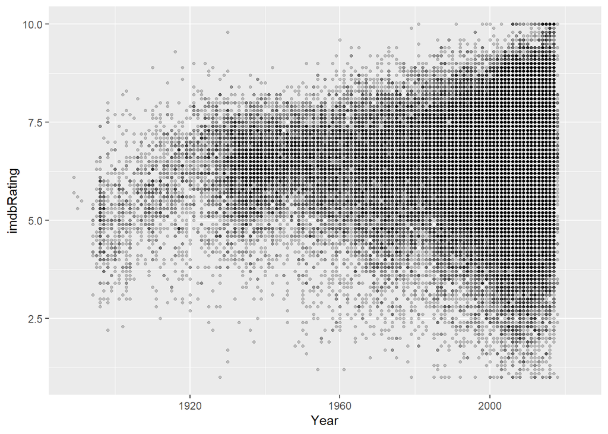

```r
# we'll save the graph into a variable so we can do other things with it later
ratings_over_time = ggplot(films,
                           aes(x = Year,           # show film release years on the x-axis
                               y = imdbRating)) +  # ... and IMDb ratings on the y-axis

  # plot a point for each film rating
  geom_point(shape = 20,     # set the shape to be a small, filled circle
             fill = "grey",  # make it grey
             alpha = 0.2)    # and make it quite faint (because there'll be a lot of overlapping points)

ratings_over_time  # display the graph
```

**Your turn:** Play with the `shape`, `fill` and `alpha` values in the code snippet above to see how they affect the graph. There’s more info about [point shapes here](https://www.datanovia.com/en/blog/ggplot-point-shapes-best-tips/) and [colours here](http://www.stat.columbia.edu/~tzheng/files/Rcolor.pdf).

Let’s add a trend line to this graph:

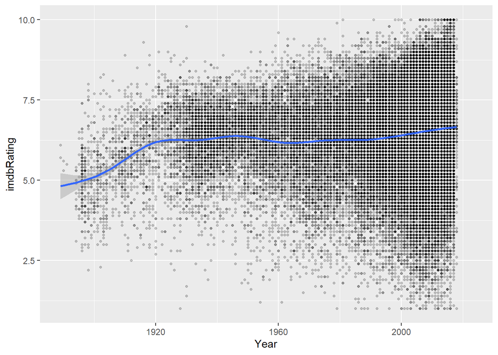

```r
ratings_over_time +
  geom_smooth()
```

According to this, film ratings seem not to have changed dramatically (on average) since 1920, although recently ratings have gotten a little higher.

## Which directors have made the most films?

Rather than just working on the entire dataset, we can filter and summarise it in various ways to answer questions. We’ll start by counting the number of films made by each director:

```r
films %>%
  filter(!is.na(Director)) %>%  # don't include records where we don't know who the director is
  count(Director) %>%           # count the number of films listed for each director
  arrange(desc(n)) %>%          # return the results with the highest counts at the top
  head()                        # show only a handful of records
```

| Director | n |
| --- | --- |
| Jim Powers | 151 |
| D.W. Griffith | 101 |
| Lewin Fitzhamon | 95 |
| Dave Fleischer | 94 |
| Al Christie | 90 |
| Georges Méliès | 86 |

Who on earth is prolific film director Jim Powers??

```r
# uncomment the code below (delete the #s) if you want to see a selection of Jim Powers titles (NSFW!)

# films %>%
#   filter(Director == "Jim Powers") %>%  # filter to keep only films directed by Jim Powers
#   select(Title) %>%                     # we just want the film titles
#   sample_n(5)                           # get a random sample of five films
```

## Which directors have made the highest-rated films?

We can do more complicated operations than just counting records. To find out which directors have made the highest-rated films, we’ll calculate the average rating per director:

```r
films %>%
  filter(!is.na(Director) & !is.na(imdbRating)) %>%  # filter out records with no director and no rating

  group_by(Director) %>%

  summarise(average_rating = mean(imdbRating),  # calculate average (mean) rating for each director's films
            number_of_films = n()) %>%          # count the number of films by each director

  filter(number_of_films > 1) %>%    # only show directors who have made more than one film
  arrange(desc(average_rating)) %>%  # return the results with the highest ratings at the top
  head()                             # show only a handful of records
```

| Director | average_rating | number_of_films |
| --- | --- | --- |
| Gustavo Goulart | 9.850000 | 2 |
| M. Glen Muse | 9.750000 | 2 |
| Lukas Hassel | 9.700000 | 2 |
| Tal Yaari | 9.700000 | 2 |
| Leslie Fanelli | 9.666667 | 3 |
| Leonard Thimo | 9.650000 | 4 |

What films has Gustavo Goulart made?

```r
films %>%
  filter(Director == "Gustavo Goulart") %>%
  select(Title, Released, Plot)
```

| Title | Released | Plot |
| --- | --- | --- |
| What the Flowers Have Brought Us | 26 Nov 2010 | Edgard and Valentina have just broke up. She feels unsure about her own future. And he's still in love with her. Now, Edgard has a plan. Old stories are about to come back. But Valentina doesn't feel … |
| Walking After You | 16 Aug 2016 | A Psycho Killer, looking for revenge, kidnaps his victim once again, because previously the victim was successful and ran away. Now, there's a new situation between the Psycho Killer and ... |

Nope, me neither.

What about films that have divided opinion? We’ll look at the spread (or *standard deviation*) of ratings, rather than the average. Larger standard deviations mean a director’s work is less consistently good (or bad).

```r
films %>%
  filter(!is.na(Director) & !is.na(imdbRating)) %>%  # filter out records with no director and no rating

  group_by(Director) %>%

  summarise(sd_rating = sd(imdbRating),  # calculate standard deviation for each director's film ratings
            number_of_films = n()) %>%   # count the number of films by each director

  filter(number_of_films > 1) %>%    # only show directors who have made more than one film
  arrange(desc(sd_rating)) %>%       # return the results with the highest ratings at the top
  head()                             # show only a handful of records
```

| Director | sd_rating | number_of_films |
| --- | --- | --- |
| Jaime Fidalgo | 5.303301 | 2 |
| Paul Watson | 4.737615 | 2 |
| Scott B. Hansen | 4.596194 | 2 |
| Paul Boyd | 4.596194 | 2 |
| Marc Ostrick | 4.525483 | 2 |
| Mike Litzenberg, Bridge Stuart | 4.525483 | 2 |

You’ll notice the only difference between the last two snippets of code is the `mean()` in the first has been replaced by `sd()` in the second.

What did Jaime Fidalgo direct and how were his films received?

```r
films %>%
  filter(Director == "Jaime Fidalgo" ) %>%
  select(Title, imdbRating)
```

| Title | imdbRating |
| --- | --- |
| In the Shower of My Mind | 1.2 |
| Soundtrack | 8.7 |

An inconsistent oeuvre…

**Your turn:** How would you calculate directors’ `median` film ratings?

```r
# enter your code here
```

## Joining datasets together

We can begin to ask more interesting questions by combining different datasets. Here’s how to join two datasets:

```r
films_actors = films %>%
  left_join(actors, by = "imdbID")      # join the `films` and `actors` dataframes together
```

The `left_join()` function takes all rows in the `films` dataframe and tries to link them to entries in the `actors` dataframe, using the column `imdbID` (the ID number of the film) to make the connection. There are several other types of join; [here’s an explanation of them](https://stat545.com/bit001_dplyr-cheatsheet.html).

Now we can ask some more interesting questions…

### Which actors have been in the highest-rated films?

Taking the `film_actors` dataset - the one that joined the `actors` dataframe to the `films` dataframe - we’ll calculate the average rating for each actor in our list:

```r
films_actors %>%
  # calculate the average rating for each actor's films, and the number of films they've been in
  group_by(Actors) %>%
  summarise(average_rating = mean(imdbRating),
            n_films = n()) %>%

  # to make it more interesting, only show results for actors who have been in more than five films
  filter(n_films > 5) %>%

  # show highest-rated actors first
  arrange(desc(average_rating)) %>%
  head()
```

| Actors | average_rating | n_films |
| --- | --- | --- |
| Eric Clapton | 7.933333 | 6 |
| Larry Mullen Jr. | 7.900000 | 8 |
| Michael J. Nelson | 7.600000 | 7 |
| George Harrison | 7.400000 | 7 |
| Clarence Nash | 7.300000 | 22 |
| Billy Connolly | 7.244444 | 9 |

### Which are the highest-rated actor-director pairs?

Similarly, we can also look at which actors have found glory with which directors. First, we’ll create a new dataframe containing pairs of actors and directors:

```r
director_actor_pairs = films %>%
  left_join(actors, by = "imdbID") %>%      # join the `films` and `actors` dataframes together
  select(Director, Actors, imdbRating) %>%  # keep only these columns
  na.omit()                                 # remove any missing records

head(director_actor_pairs)
```

| Director | Actors | imdbRating |
| --- | --- | --- |
| Matt Hish | Rib Hillis | 2.4 |
| Meiert Avis | Ian Grushka | 6.3 |
| Fendou Liu | Jiawei Xia | 5.5 |
| Terry L. Noss, Richard Rich | Seth Green | 5.0 |
| Joseph Kane | Richard Jaeckel | 7.6 |
| Ernst L. Frank | Grant Mitchell | 6.8 |

Let’s look at which have been the most successful actor-director relationships (in terms of IMDb ratings):

```r
director_actor_pairs %>%
  group_by(Director, Actors) %>%
  summarise(average_rating = mean(imdbRating),
            n_films = n()) %>%

  filter(n_films > 2) %>%
  arrange(desc(average_rating))
```

| Director | Actors | average_rating | n_films |
| --- | --- | --- | --- |
| Anestis Dalezis, Leonard Thimo | Leonard Thimo | 8.866667 | 3 |
| Rocco Urbisci | George Carlin | 8.700000 | 3 |
| Emilie de Azevedo Brown | Rachel Coleman | 8.333333 | 3 |
| Jonathan Lajoie | Jonathan Lajoie | 8.133333 | 3 |
| Larry Rosen | Larry Rosen | 8.133333 | 3 |
| Jules White | Moe Howard | 7.900000 | 3 |
| Viv Thomas | Jamie | 7.900000 | 3 |
| Joseph Barbera, William Hanna | Lillian Randolph | 7.833333 | 3 |
| Dan Eckman | D.C. Pierson | 7.800000 | 4 |
| James Algar | Winston Hibler | 7.800000 | 3 |

[output cut: 114 more lines]

Leonard Thimo directing himself, it seems. George Carlin does pretty well out of it too.

# Bringing in other sources of data

So far we’ve just been using data from a single source: IMDb. Analyses get really interesting when you can combine (or ‘link’) related datasets from different sources.

IMDb ratings aren’t the be all and end all. Let’s look at film ratings from Rotten Tomatoes:

```r
# load film ratings from other data sources
add_ratings = read_csv("data/Movie_AdditionalRating.csv")
# we only need to keep the film ID (imdbID) and the Rotten Tomatoes rating
add_ratings = add_ratings %>%
  filter(RatingSource == "Rotten Tomatoes") %>%  # keep only the Rotten Tomatoes ratings
  select(imdbID,
         tomsRating = Rating) %>%   # rename this column to `tomsRating`, to distinguish it from the IMDb one
  distinct()  # remove any duplicates
```

We’ll need to tweak the format because Rotten Tomatoes ratings are given as percentages…

```r
# show five random Rotten Tomatoes ratings
sample(add_ratings$tomsRating, 5)
```

```
## [1] "93%"  "60%"  "76%"  "100%" "10%"
```

… whereas IMDb ratings are scores out of ten:

```r
# show five random IDMb ratings
sample(films$imdbRating, 5)
```

```
## [1] 5.6 6.7  NA 7.7  NA
```

To make them comparable, we can convert the Rotten Tomatoes percentages into scores out of ten:

```r
add_ratings = add_ratings %>%
  mutate(tomsRating = str_remove(tomsRating, "%")) %>%  # get rid of percentage signs
  mutate(tomsRating = as.integer(tomsRating)) %>%       # convert from a string to an integer
  mutate(tomsRating = tomsRating / 10)                  # make it out of ten rather than 100

head(add_ratings)
```

| imdbID | tomsRating |
| --- | --- |
| tt0206367 | 1.5 |
| tt0098347 | 1.3 |
| tt2140619 | 4.0 |
| tt1305027 | 6.0 |
| tt0326969 | 10.0 |
| tt1776196 | 8.5 |

Now we can merge these scores into the main `films` dataframe:

```r
films = films %>%
  left_join(add_ratings, by = "imdbID")
```

Calculate (and plot) discrepancies between IMDb ratings and Rotten Tomatoes scores:

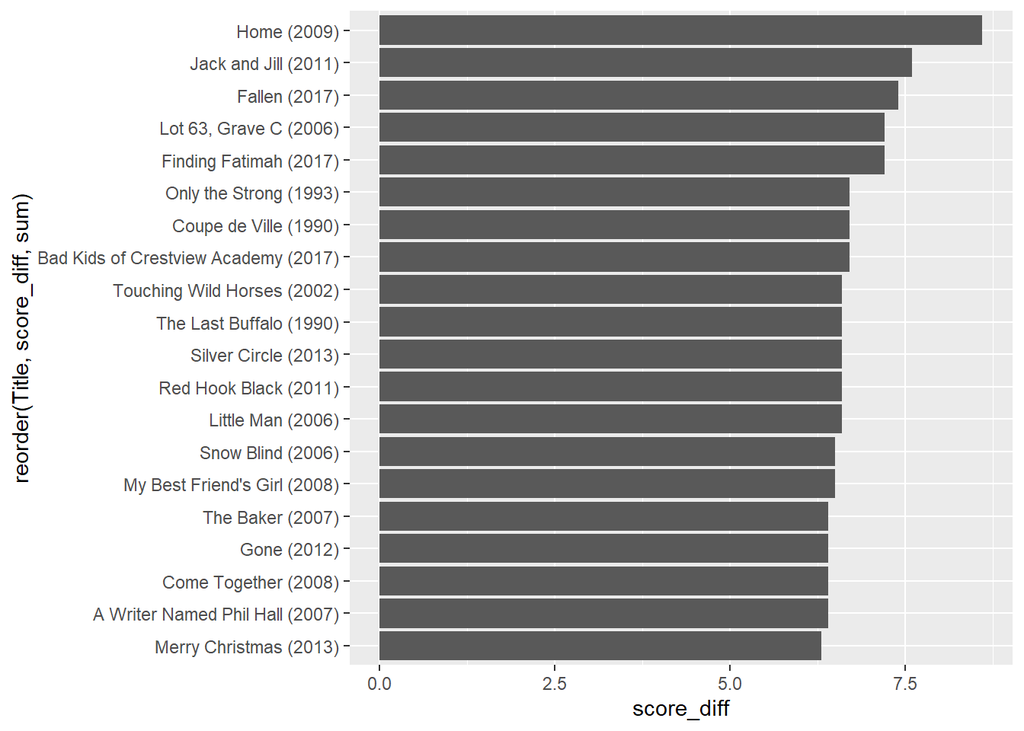

```r
films %>%
  mutate(score_diff = abs(imdbRating - tomsRating)) %>%  # calculate absolute difference in ratings
  mutate(Title = paste0(Title, " (", Year, ")")) %>%     # append release year to the title (for graph)

  filter(!is.na(score_diff)) %>%  # get rid of films without a score
  arrange(desc(score_diff)) %>%   # put largest discrepancies first
  head(20) %>%                    # keep 20 largest discrepancies

  # plot the discrepancies on a graph
  ggplot(aes(x = reorder(Title, score_diff, sum),  # re-order x-axis so largest discrepancies come first
             y = score_diff)) +

  geom_col() +  # draw a bar chart
  coord_flip()  # flip so that film titles are on the y-axis
```

# A more advanced analysis: Film ratings compared to duration

Given all these building blocks, we can start to do something a little more advanced. This section will cover some nifty data-wrangling, a bit of maths, some statistics, and a *ridiculously* long film.

To get started, we need to calculate each film’s running time. At the moment, they’re stored as strings of text, along the lines of “100 min” or “2 h 5 min”. This block of code will do some string manipulation (using [regular expressions](https://regexr.com/)) and reshaping of data to convert these running times into numbers, representing a film’s duration in minutes:

```r
ratings_duration = films %>%
  # keep only the columns we need for the graph
  select(imdbID, Runtime, imdbRating, tomsRating) %>%

  # get rid of any rows with missing data
  # filter(!is.na(Runtime)) %>%
  # na.omit() %>%

  # use a regular expression to extract only the numbers from the Runtime column - e.g. "2 h 5 min" will become two columns containing "2" and "5"
  mutate(Runtime = str_remove(Runtime, ",")) %>%   # some numbers are separated by commas - get rid of the commas
  mutate(duration = str_extract_all(Runtime, "[0-9]+")) %>%
  select(-Runtime) %>%
  unnest(duration) %>%

  # each film could now have multiple rows (if its running time contained more than one number); convert these into separate columns for each number
  group_by(imdbID) %>%
  mutate(number = paste0("time_", row_number())) %>%
  ungroup() %>%
  spread(number, duration) %>%

  # by default the numbers are stored as character strings; convert them to numbers
  mutate(time_1 = as.double(time_1),
         time_2 = as.double(time_2))

# convert running time to minutes
ratings_duration = ratings_duration %>%
  mutate(Duration = case_when(
    !is.na(time_2) ~ (time_1 * 60) + time_2,  # contains hours and minutes; convert hours to minutes and add up
    is.na(time_2) ~ time_1                    # only contains minutes; use as is
  )) %>%

  select(-time_1, -time_2)  # don't need the separate time columns anymore so drop them

  # filter(!is.na(Duration)) %>%                     # filter out films without a running time


head(ratings_duration)
```

| imdbID | imdbRating | tomsRating | Duration |
| --- | --- | --- | --- |
| tt0000012 | 7.4 | NA | 1 |
| tt0000035 | 5.4 | NA | NA |
| tt0000054 | 5.8 | NA | NA |
| tt0000068 | 4.3 | NA | NA |
| tt0000079 | 4.4 | NA | NA |
| tt0000080 | 4.6 | NA | NA |

Now we have a dataframe containing IMDb ratings and film durations (in minutes). Now for some statistics. Let’s look at the correlation between ratings and duration:

```r
cor.test(ratings_duration$imdbRating, ratings_duration$Duration)
```

```
##
##  Pearson's product-moment correlation
##
## data:  ratings_duration$imdbRating and ratings_duration$Duration
## t = -8.7259, df = 53267, p-value < 2.2e-16
## alternative hypothesis: true correlation is not equal to 0
## 95 percent confidence interval:
##  -0.04625816 -0.02929830
## sample estimates:
##         cor
## -0.03778095
```

The relationship between these two variables is [statistically significant](https://towardsdatascience.com/statistical-significance-hypothesis-testing-the-normal-curve-and-p-values-93274fa32687) because the p-value is way below the standard threshold of 0.05 (`p-value < 2.2e-16`). However, the size of the correlation is almost zero (-0.038, with a [95% confidence interval](https://www.dummies.com/education/science/biology/confidence-interval-basics/) of [-0.029, -0.046]), suggesting there is no relationship between running time and ratings.

**Your turn:** How would you test the correlation between Rotten Tomatoes ratings (`tomsRating`) and film duration (`Duration`)?

```r
# enter your code here
```

The relationship between ratings and duration becomes a bit clearer if we plot them together on a graph:

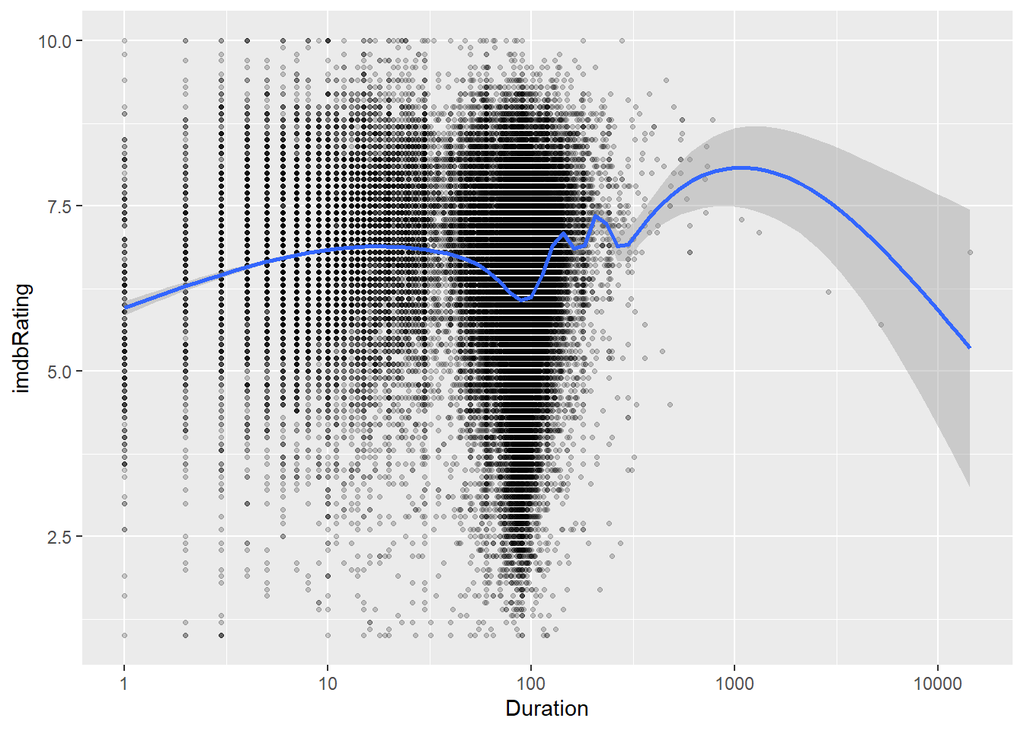

```r
ggplot(ratings_duration, aes(x = Duration, y = imdbRating)) +

  # plot a point for each film
  # **play with these values to see how it affects the graph**
  geom_point(shape = 20,     # set the shape to be a small, filled circle
             fill = "grey",  # make it grey
             alpha = 0.2) +  # and make it quite faint (because there'll be a lot of overlapping points)

  # some films are insanely long and some are incredibly short; plot them on a logarithmic scale so the mid-length films don't get squished
  scale_x_log10() +

  # add a trend line
  geom_smooth()
```

Not much of a trend. The outlier all the way to the right of the graph is 2011’s epic Finnish Documentary, [Modern Times Forever](https://www.imdb.com/title/tt2659636/) - a film that lasts TEN DAYS from start to finish!

```r
# get details for the longest film
films %>%
  left_join(ratings_duration, by = "imdbID") %>%
  filter(Duration == max(ratings_duration$Duration, na.rm = TRUE)) %>%  # filter the film with the max. duration of all films in the dataframe
  select(imdbID, Title, Director, Runtime)
```

| imdbID | Title | Director | Runtime |
| --- | --- | --- | --- |
| tt2659636 | Modern Times Forever | Bjornstjerne Reuter Christiansen, Jakob Fenger, Rasmus Nielsen, Superflex | 14,400 min |

# Bonus: word cloud of film titles

We’ll use the `tidytext` package to get the film titles into an orderly dataframe and the `wordcloud` package to visualise it.

```r
# install.packages("tidytext", "wordcloud")

library(tidytext)
library(wordcloud)
```

First we need to separate the words from each film title (known as ‘tokenisation’) and count the number of times each word appears:

```r
film_title_words = films %>%
  select(imdbID, Title) %>%

  # separate the words out from each film title
  unnest_tokens(word, Title) %>%

  # count the number of times each word appears
  count(word, sort = TRUE) %>%
  ungroup()
```

Get rid of common words like ‘the’ and ‘a’ (known as “stop words”):

```r
data("stop_words")

film_title_words = film_title_words %>%
  anti_join(stop_words)
```

Get rid of numbers (e.g. ‘2’ from ‘Toy Story 2’):

```r
nums = film_title_words %>%
  filter(str_detect(word, "^[0-9]")) %>%
  select(word) %>%
  unique()

film_title_words = film_title_words %>%
  anti_join(nums, by = "word")
```

Draw the word cloud:

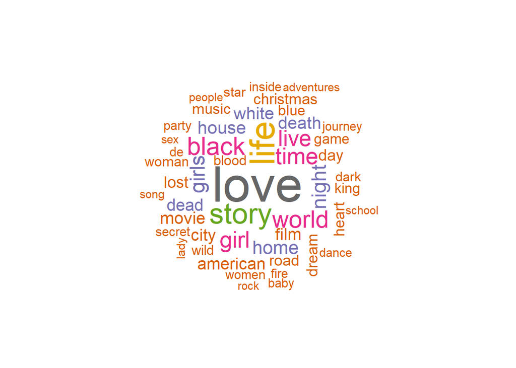

```r
# define a nice color palette
pal = brewer.pal(8, "Dark2")

# plot the 50 most common words
film_title_words %>%
  with(wordcloud(word, n, random.order = FALSE, max.words = 50, colors = pal))
```

An even better version of this would only use the stems of words (e.g. ‘girl’ for both ‘girls’ and ‘girl’). You can do this yourself using the [`hunspell` package](https://docs.ropensci.org/hunspell/)…